# Wolverine 2022 Inference

Brian D. Gerber and Jacob S. Ivan

2025-8-1

## **Inference**

To investigate spatial factors affecting wolverine occupancy, we will use non-spatial Bayesian single-season occupancy models (via the R package UBMS and Unmarked). These models are more straightforward to interpret as there is no trading off between the spatial covariates of interest and a generalized spatial neighborhood process (used in the spatial occupancy model); the spatial occupancy models is intended for prediction, rather than inference.

To consider the spatial variables that influence wolverines occurence, we should only consider areas that have wolverines (Montana, Washington, Wyoming, Idaho). The states that do not have wolverines (or detected wolverines; Colorado, Utah, Oregon) do not help us understand the spatial factors because there are no wolverines available to select a certain site and not another site. Therefore, this analysis is limited to the 4-state sampling frame.

## **Covariates**

These variables were derived by Jake Ivan and confirmed to be accurate.

### *Spatial Plots*

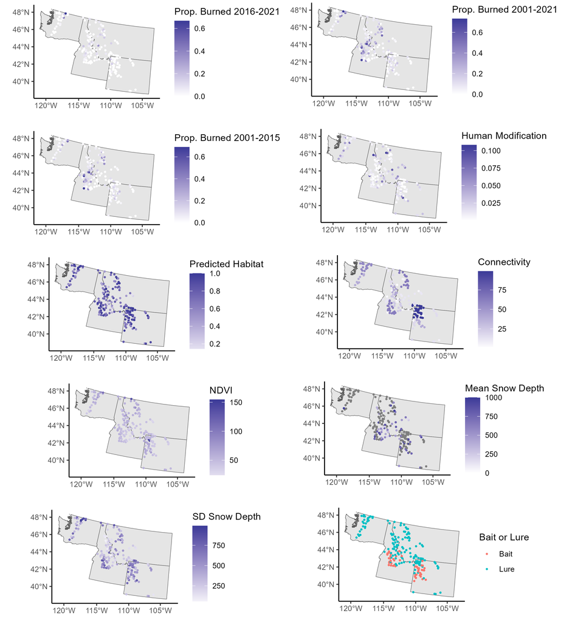

### *Covariate Correlations*

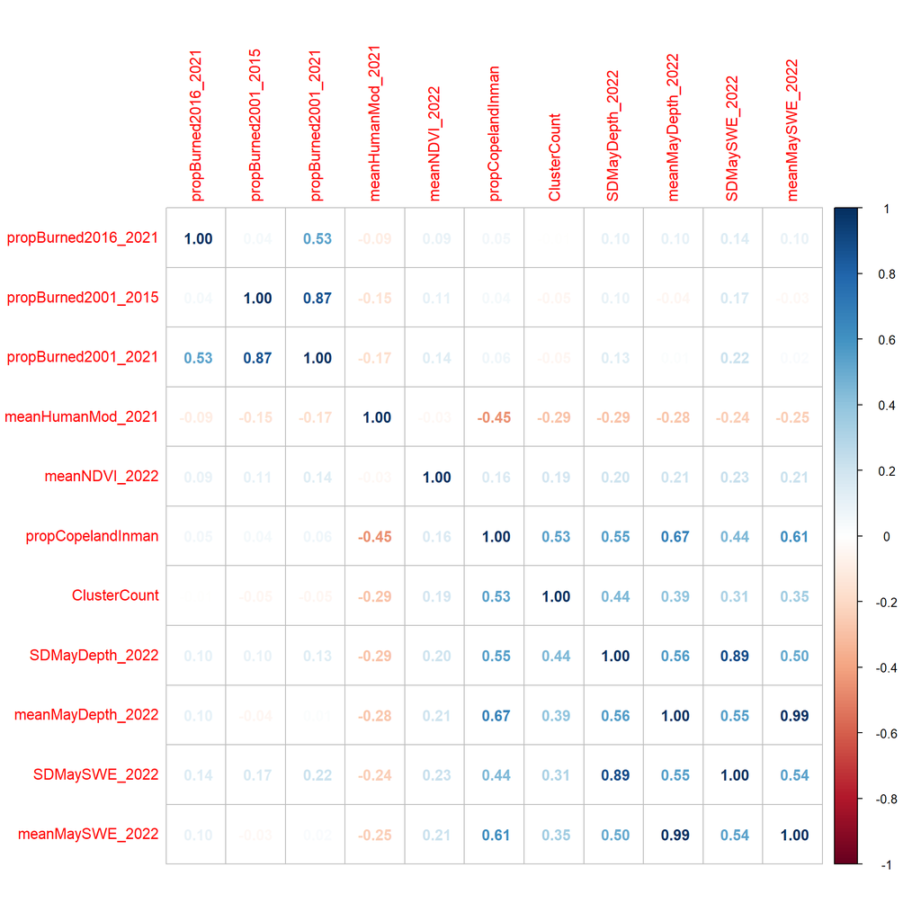

**Noted High Pairwise Correlations**

*Preferred covariates in bold:*

- propBurned2001_2021 and **propBurned2016_2021**
- propCopelandInman and **meanHumanMod_2021** ; medium correlation.
- propCopelandInman and **ClusterCount and snow measures**
- All snow measures are correlated. Use **MeanMayDepth2022**.

## **Models**

We considered three models. In each, the variables hypothesized to effect occupancy varied (see below; general summary of the model and model syntax) while detection probability was always hypothesized to be effected by whether a site had bait or lure.

- **Model 1:** Human Modification*Habitat Connectivity
  - meanHumanMod_2021*ClusterCount
- **Model 2:** Environmental model (NDVI with quadratic, burn, and Snow with quadratic)
  - meanNDVI_2022 + I(meanNDVI_2022^2) + propBurned2016_2021 + propBurned2001_2015 + meanMayDepth_2022 + I(meanMayDepth_2022^2)
- **Model 3:** Simple Environmental and Human Modification with Connectivity
  - meanHumanMod_2021 + ClusterCount + meanNDVI_2022 + propBurned2016_2021 + propBurned2001_2015 + meanMayDepth_2022

## **Results**

### *Model Comparison*

Model 3 was most supported, as measured by expected log-poinwise predicted density (elpd). However, there isn’t that much difference among models, especically when considering the variation (se_diff).

|  | elpd | nparam | elpd_diff | se_diff |
| --- | --- | --- | --- | --- |
| Model3 | -210.723 | 14.384 | 0.000 | 0.000 |
| Model1 | -212.666 | 11.702 | -1.943 | 3.316 |
| Mode2 | -218.209 | 15.535 | -7.486 | 3.836 |

### *MCMC Convergence*

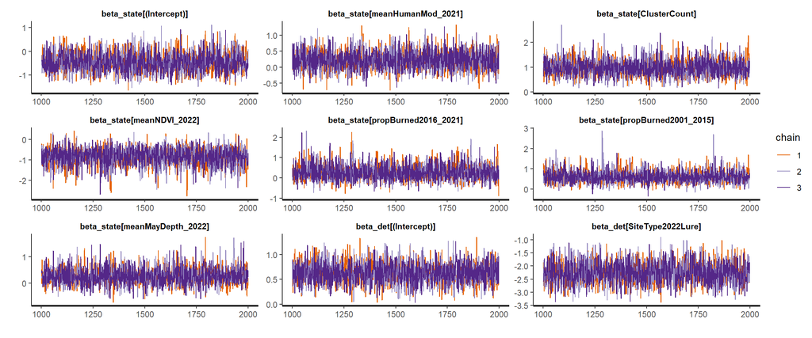

All parameter from the most supported model have convereged.

### *Goodness of fit*

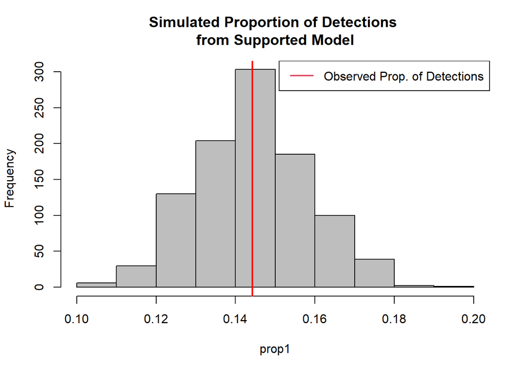

No departure of model fit using this test statistic.

### *Model Summary*

```
##
## Call:
## stan_occu(formula = ~SiteType2022 ~ meanHumanMod_2021 + ClusterCount +
##     meanNDVI_2022 + propBurned2016_2021 + propBurned2001_2015 +
##     meanMayDepth_2022, data = umf.2022, chains = 3, iter = 2000,
##     cores = 3, seed = 123)
##
## Occupancy (logit-scale):
##                     Estimate    SD   2.5%  97.5% n_eff Rhat
## (Intercept)           -0.442 0.401 -1.174  0.397  1864    1
## meanHumanMod_2021      0.230 0.287 -0.316  0.807  2496    1
## ClusterCount           0.988 0.327  0.404  1.694  2426    1
## meanNDVI_2022         -0.857 0.432 -1.787 -0.120  2193    1
## propBurned2016_2021    0.283 0.384 -0.353  1.129  2018    1
## propBurned2001_2015    0.618 0.307  0.108  1.336  1580    1
## meanMayDepth_2022      0.268 0.316 -0.305  0.939  2150    1
##
## Detection (logit-scale):
##                  Estimate    SD   2.5% 97.5% n_eff Rhat
## (Intercept)         0.632 0.206  0.233  1.05  2747    1
## SiteType2022Lure   -2.256 0.400 -3.018 -1.44  1737    1
##
## LOOIC: 421.446
## Runtime: 4.262 sec
```

### *Probability of Support*

|  | Probability>0 |
| --- | --- |
| Occ.Intercept | 0.16 |
| Occ.meanHumanMod_2012 | 0.77 |
| Occ.ClusterCount | 1.00 |
| Occ.meanNDVI2022 | 0.02 |
| Occ.PropBurned2016-2021 | 0.78 |
| Occ.PropBurned2001-2015 | 0.99 |
| Occ_MeanMayDepth | 0.79 |
| Det.Intercept | 1.00 |
| Det.SiteType | 0.00 |

A probability near 1 indicates a strong support for a positive effect.

A probability near 0 indicates a strong support for a negative effect.

Probabilities between 0.1 and 0.9 indicate mild or no statistical support.

### *Marginal Effect Plots*

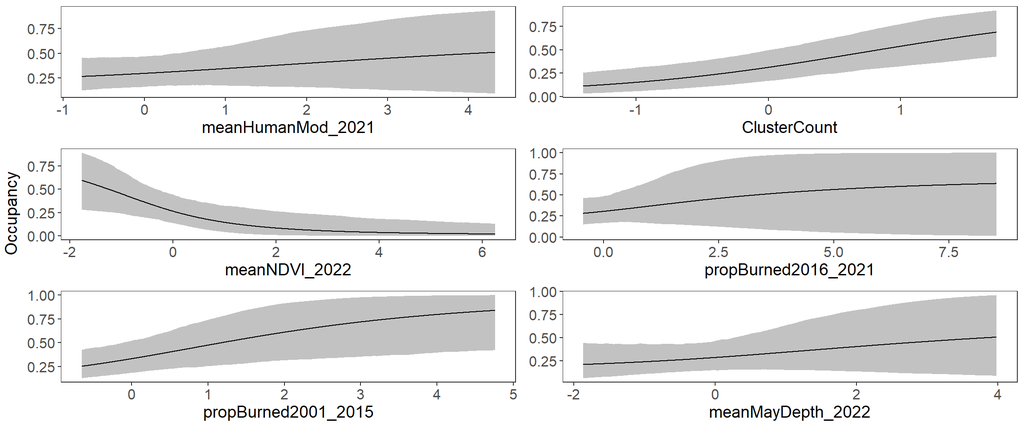

Note that the x-axes vary, based on the standardization of the variable.

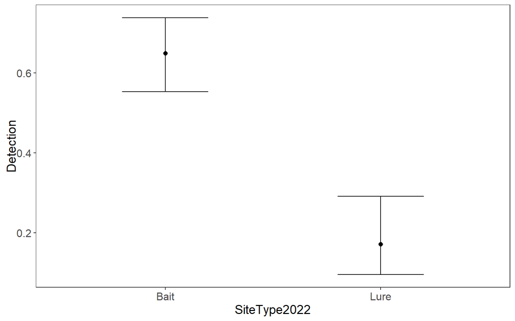

## **Summary**

- There is clear statistical support that increasing connectivity (`ClusterCount`) leads to increase wolverine occupancy.
- There is clear statistical support that increasing `meanNDVI_2022` leads to decreasing wolverine occupancy.
- There is clear statistical support that increasing old fires (`PropBurned2001-2015`) leads to increasing wolverine occupancy.
- There is clear statistical support that lure decreases the probability of detection at an occupied site relative to bait sites.

## **References**

Vehtari, A., Gelman, A., and Gabry, J. (2017). Practical Bayesian model evaluation using leave-one-out cross-validation and WAIC. Statistics and Computing. 27(5), 1413–1432. doi:10.1007/s11222-016-9696-4